# Modeling and prediction for movies

## Setup

### Load packages

```r
options (warn = -1)
suppressMessages(library(ggplot2))
library(dplyr)
library(statsr)
library(GGally)
library(gridExtra)
```

### Load data

It is assumed that the compressed dataset (gz) and rmd files are in the same working directory, else please load.

This command loads the movies data with 651 rows and 32 variables.

```r
load("movies.gz")
```

## Part 1: Data

The IMDB & Rotten Tomatoes are both large databases of movies and entertainment titles with data coming from various sources and cover international titles. The sample database provided for this exercise filters US movies, also movies in the sample provided are for the period 1970 onwards, whereas the IMDB database includes movie data since 1874 (approx 4.6million movies).

The IMDB dataset contains observational data based collected from various sources and due to size and independent variety of sources could be categorized as random.

The data being used for this project is a random sample focusing on US movie data extracted from the IMBDB database. The distribution of some key variables is examined later.

**As such the inference from this exercise will have generalizability limited to the filters used in selecting the sample that is for US movies and limited to the period 1970-2016. The inference will not have causal use due to lack of random assignment.**

## Part 2: Research question

As stated in the project, the boss at Paramount Pictures is interested in learning what attributes make a movie popular. The boss is also interested in learning something new about movies.

Specifically, I have framed the research question as:

**Can a movie’s popularity (imdb_rating is the response variable) be predicted based on other variables in the imdb sample database.**

**Specifically, based on analysis I have narrowed it down to “Can the imdb_rating be predicted from critics_score, audience_score and imdb_num_votes”.**

This research would be on interest to predict imdb_ratings of movies and hence have insights into potential top box office hits.

## Part 3: Exploratory data analysis

This reduces the dataset to be explored down to 12 columns.

I have also removed the last 7 rows (rows 645 thru 651) and used them as validation/test data to test the model in the prediction phase

```r
rem_cols <- c(-(2:12),-17,-(25:32))
movies_new <- movies[-(645:651),rem_cols]
str(movies_new)
```

```
## Classes 'tbl_df', 'tbl' and 'data.frame':    644 obs. of  12 variables:
##  $ title           : chr  "Filly Brown" "The Dish" "Waiting for Guffman" "The Age of Innocence" ...
##  $ imdb_rating     : num  5.5 7.3 7.6 7.2 5.1 7.8 7.2 5.5 7.5 6.6 ...
##  $ imdb_num_votes  : int  899 12285 22381 35096 2386 333 5016 2272 880 12496 ...
##  $ critics_rating  : Factor w/ 3 levels "Certified Fresh",..: 3 1 1 1 3 2 3 3 2 1 ...
##  $ critics_score   : num  45 96 91 80 33 91 57 17 90 83 ...
##  $ audience_score  : num  73 81 91 76 27 86 76 47 89 66 ...
##  $ best_pic_nom    : Factor w/ 2 levels "no","yes": 1 1 1 1 1 1 1 1 1 1 ...
##  $ best_pic_win    : Factor w/ 2 levels "no","yes": 1 1 1 1 1 1 1 1 1 1 ...
##  $ best_actor_win  : Factor w/ 2 levels "no","yes": 1 1 1 2 1 1 1 2 1 1 ...
##  $ best_actress_win: Factor w/ 2 levels "no","yes": 1 1 1 1 1 1 1 1 1 1 ...
##  $ best_dir_win    : Factor w/ 2 levels "no","yes": 1 1 1 2 1 1 1 1 1 1 ...
##  $ top200_box      : Factor w/ 2 levels "no","yes": 1 1 1 1 1 1 1 1 1 1 ...
```

I plot out the numerical variables of interest to get a preliminary look at their distribution.

```r
summary(movies_new[,2:6])
```

```
##   imdb_rating  imdb_num_votes           critics_rating critics_score
##  Min.   :1.9   Min.   :   180   Certified Fresh:134    Min.   :  1.00
##  1st Qu.:5.9   1st Qu.:  4516   Fresh          :208    1st Qu.: 33.00
##  Median :6.6   Median : 15070   Rotten         :302    Median : 61.50
##  Mean   :6.5   Mean   : 57660                          Mean   : 57.81
##  3rd Qu.:7.3   3rd Qu.: 58117                          3rd Qu.: 83.00
##  Max.   :9.0   Max.   :893008                          Max.   :100.00
##  audience_score
##  Min.   :11.00
##  1st Qu.:46.00
##  Median :65.00
##  Mean   :62.49
##  3rd Qu.:80.00
##  Max.   :97.00
```

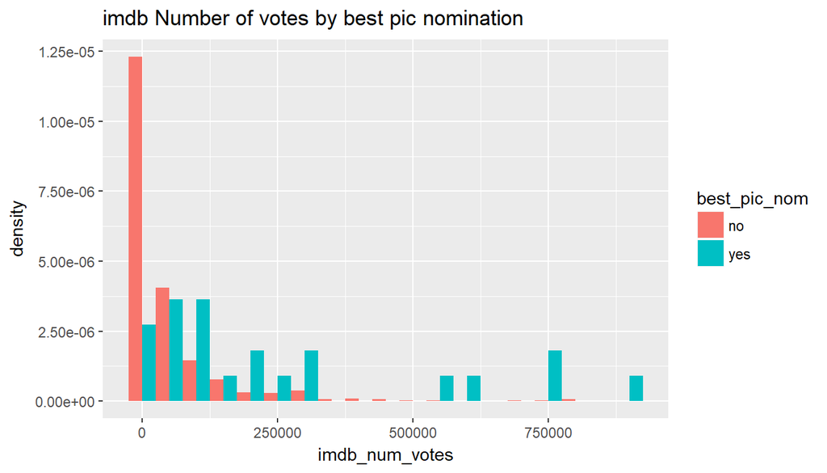

```r
ggplot (movies_new,aes(x=imdb_num_votes,fill=best_pic_nom)) + geom_histogram(aes(y=..density..),binwidth=50000,position='dodge') + labs(title='imdb Number of votes by best pic nomination')
```

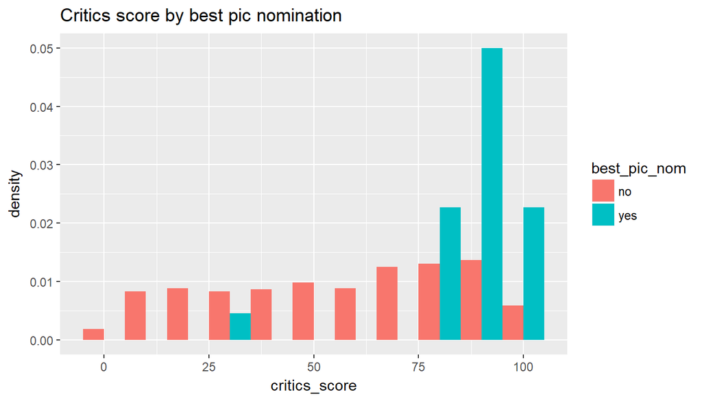

```r
ggplot (movies_new,aes(x=critics_score,fill=best_pic_nom)) + geom_histogram(aes(y=..density..),binwidth=10,position='dodge') + labs(title='Critics score by best pic nomination')
```

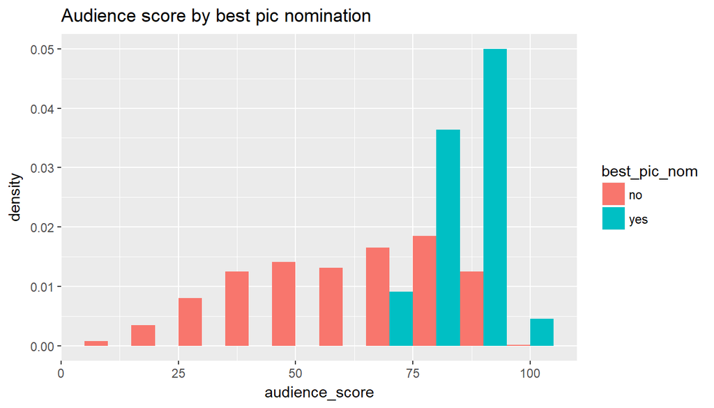

```r
ggplot (movies_new,aes(x=audience_score,fill=best_pic_nom)) + geom_histogram(aes(y=..density..),binwidth=10,position='dodge') + labs(title='Audience score by best pic nomination')
```

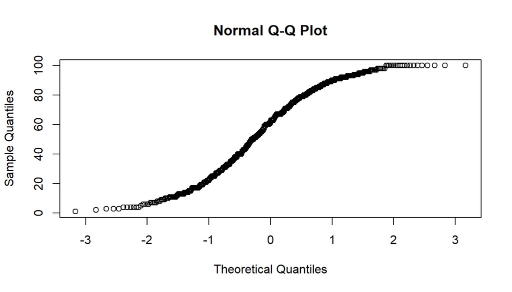

```r
qqnorm(movies_new$critics_score)
```

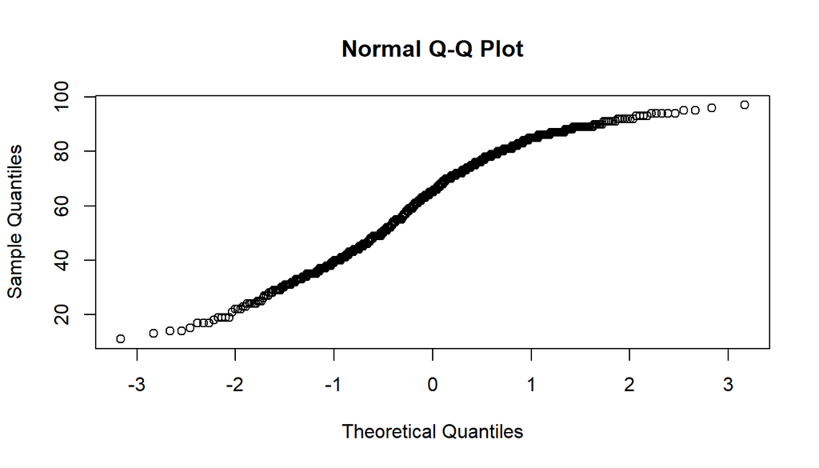

```r
qqnorm(movies_new$audience_score)
```

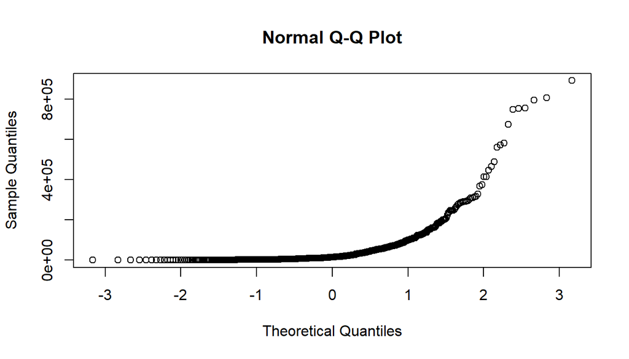

```r
qqnorm(movies_new$imdb_num_votes)
```

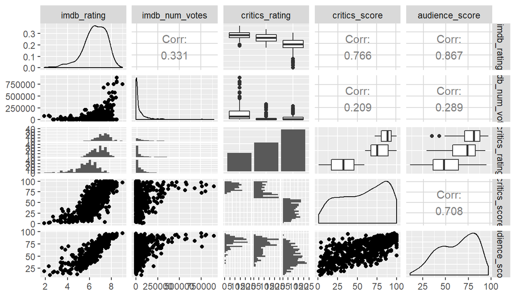

```r
ggpairs(movies_new[,2:6])
```

The ggpairs plot shows pair plots between these 5 variables. It also shows high collinearity between explanatory variables (audience_score & critics-score): Corr is 0.708 suggesting one of them can be eliminated. However, I have chosen to keep both for now since they do come from independent sources.

The imdb_num_votes seem to impact all the score variables. A higher # of votes indicates higher audience scores and critics score. Whereas the same is not necessarily true at low imdb_num_votes.

Based the pairs chart, I did not yet eliminate any of the numerical variables. Would like to do it as part of modeling using their ‘p’ values

Next I explore relationship between best_pic_nom, critics_score and audience_score to see which is a better indicator.

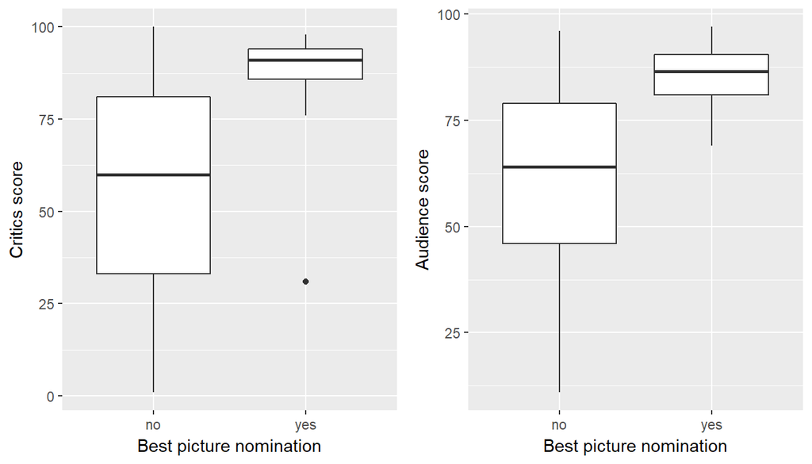

```r
p1 <- ggplot(movies_new,aes(y=movies_new$critics_score,x=movies_new$best_pic_nom)) + geom_boxplot() + ylab('Critics score') + xlab('Best picture nomination' )
p2 <- ggplot(movies_new,aes(y=movies_new$audience_score,x=movies_new$best_pic_nom)) + geom_boxplot() + ylab ('Audience score') + xlab('Best picture nomination')
grid.arrange(p1,p2,ncol=2)
```

From the above side-by-side box plot, it seems that both critic and audience scores are similar in how they co-relate to best picture nominations. The movies getting nominated have a higher median than movies not high on critic and audience scores.

Based on this, I eliminated best_pic_nom from the linear regression modelling shown later in this project. I have also dropped critics_rating in favor of critics_score since it is quantitiative and possibly derived from it

Also have explored the imdb_num_votes further as it relates to best_pic_nom and top200_box.

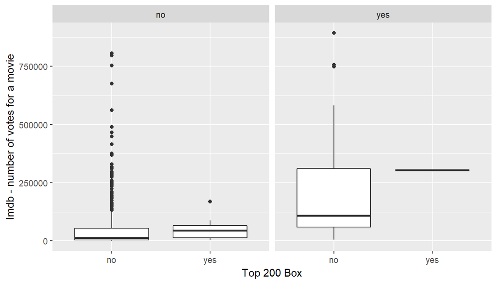

```r
ggplot (movies_new,aes(y=imdb_num_votes,x=movies_new$top200_box)) + geom_boxplot() + facet_grid(~best_pic_nom) + xlab('Top 200 Box') + ylab('Imdb - number of votes for a movie')
```

**Full Model**

From the above plots & analysis, it seems a linear relationship of imdb_rating with imdb_num_votes, audience_score, critics_score, best_pic_nom and top200_box could be worth exploring to start with and then drop any features not contributing by looking at p values.

As the next step, the model is run in multiple iterations to further simplify by:

- examining ‘p’ values to select a variable to be dropped, and
- noting the impact on R-squared.

## Part 4: Modeling

### 1st iteration: 5 explantory variables included:

**All 5 variables are included in the modeler, giving adj. R-square of 0.8044, highest p = best_pic_nom at .767, which is dropped in the next iteration**

```r
summary(lm(imdb_rating ~ audience_score + critics_score + top200_box + best_pic_nom + imdb_num_votes,data=movies_new))
```

```
##
## Call:
## lm(formula = imdb_rating ~ audience_score + critics_score + top200_box +
##     best_pic_nom + imdb_num_votes, data = movies_new)
##
## Residuals:
##      Min       1Q   Median       3Q      Max
## -2.49192 -0.19192  0.02619  0.29349  1.16348
##
## Coefficients:
##                   Estimate Std. Error t value Pr(>|t|)
## (Intercept)      3.673e+00  6.251e-02  58.748  < 2e-16 ***
## audience_score   3.367e-02  1.356e-03  24.838  < 2e-16 ***
## critics_score    1.169e-02  9.451e-04  12.371  < 2e-16 ***
## top200_boxyes   -2.235e-01  1.361e-01  -1.643    0.101
## best_pic_nomyes -3.304e-02  1.113e-01  -0.297    0.767
## imdb_num_votes   9.281e-07  1.904e-07   4.876 1.37e-06 ***
## ---
## Signif. codes:  0 '***' 0.001 '**' 0.01 '*' 0.05 '.' 0.1 ' ' 1
##
## Residual standard error: 0.4796 on 638 degrees of freedom
## Multiple R-squared:  0.8059, Adjusted R-squared:  0.8044
## F-statistic: 529.9 on 5 and 638 DF,  p-value: < 2.2e-16
```

### 2nd iteration: drop best_pic_nom

```r
summary(lm(imdb_rating ~ audience_score + critics_score + top200_box + imdb_num_votes,data=movies_new))
```

```
##
## Call:
## lm(formula = imdb_rating ~ audience_score + critics_score + top200_box +
##     imdb_num_votes, data = movies_new)
##
## Residuals:
##     Min      1Q  Median      3Q     Max
## -2.4925 -0.1915  0.0295  0.2935  1.1646
##
## Coefficients:
##                  Estimate Std. Error t value Pr(>|t|)
## (Intercept)     3.675e+00  6.207e-02  59.198  < 2e-16 ***
## audience_score  3.365e-02  1.353e-03  24.871  < 2e-16 ***
## critics_score   1.167e-02  9.422e-04  12.388  < 2e-16 ***
## top200_boxyes  -2.228e-01  1.359e-01  -1.639    0.102
## imdb_num_votes  9.124e-07  1.827e-07   4.994 7.64e-07 ***
## ---
## Signif. codes:  0 '***' 0.001 '**' 0.01 '*' 0.05 '.' 0.1 ' ' 1
##
## Residual standard error: 0.4792 on 639 degrees of freedom
## Multiple R-squared:  0.8059, Adjusted R-squared:  0.8047
## F-statistic: 663.3 on 4 and 639 DF,  p-value: < 2.2e-16
```

### 3rd iteration - drop top200_box

With best_pic_nom dropped, we now have R-squared increase to 0.804 with top200_box being the highest p value at .102. I drop this variable and run the modelor again

```r
summary(lm(imdb_rating ~ imdb_num_votes + audience_score + critics_score,data=movies_new))
```

```
##
## Call:
## lm(formula = imdb_rating ~ imdb_num_votes + audience_score +
##     critics_score, data = movies_new)
##
## Residuals:
##      Min       1Q   Median       3Q      Max
## -2.48905 -0.18726  0.02629  0.29443  1.17193
##
## Coefficients:
##                 Estimate Std. Error t value Pr(>|t|)
## (Intercept)    3.677e+00  6.214e-02  59.172  < 2e-16 ***
## imdb_num_votes 8.279e-07  1.755e-07   4.717 2.94e-06 ***
## audience_score 3.368e-02  1.355e-03  24.861  < 2e-16 ***
## critics_score  1.160e-02  9.425e-04  12.311  < 2e-16 ***
## ---
## Signif. codes:  0 '***' 0.001 '**' 0.01 '*' 0.05 '.' 0.1 ' ' 1
##
## Residual standard error: 0.4799 on 640 degrees of freedom
## Multiple R-squared:  0.8051, Adjusted R-squared:  0.8042
## F-statistic: 881.2 on 3 and 640 DF,  p-value: < 2.2e-16
```

we are left with 3 variables and adj R-squared unchanged at .804. The p values of the 3 remaining variable are << 0, with the highest being for imdb_num_votes. I drop this variable to check the impact, although p is very low for it, almost 0.

### 4th iteration - dropimdb_num_votes to check impact

```r
summary(lm(imdb_rating ~ audience_score + critics_score,data=movies_new))
```

```
##
## Call:
## lm(formula = imdb_rating ~ audience_score + critics_score, data = movies_new)
##
## Residuals:
##      Min       1Q   Median       3Q      Max
## -2.53208 -0.19913  0.03219  0.30182  1.22557
##
## Coefficients:
##                Estimate Std. Error t value Pr(>|t|)
## (Intercept)    3.641301   0.062693   58.08   <2e-16 ***
## audience_score 0.034989   0.001348   25.96   <2e-16 ***
## critics_score  0.011630   0.000958   12.14   <2e-16 ***
## ---
## Signif. codes:  0 '***' 0.001 '**' 0.01 '*' 0.05 '.' 0.1 ' ' 1
##
## Residual standard error: 0.4878 on 641 degrees of freedom
## Multiple R-squared:  0.7983, Adjusted R-squared:  0.7977
## F-statistic:  1269 on 2 and 641 DF,  p-value: < 2.2e-16
```

Dropping imdb_num_votes reduces adj R-square to 0.79. I tried dropping the other 2 features individually, both reduce adj R square - hence decided to leave them in the final model.

### The final model is

imdb_rating ~ audience score + critics score + imdb_num_votes

### Checking for model fit and residual distribution

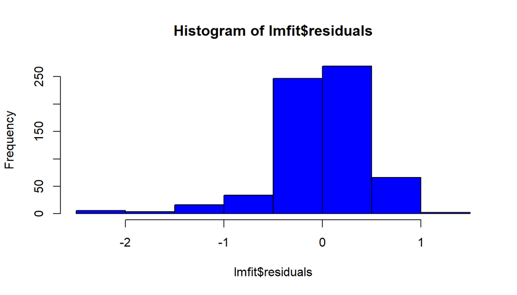

```r
# save the final model in lmfit

lmfit <- lm(imdb_rating ~ imdb_num_votes + audience_score + critics_score,data=movies_new)


# scatter and histogram plot for residuals
hist(lmfit$residuals,col='blue')
```

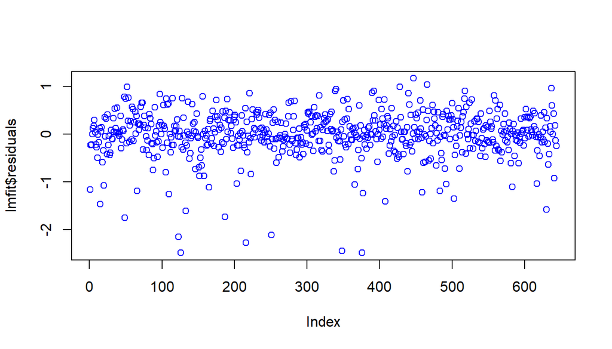

```r
plot(lmfit$residuals,col='blue')
```

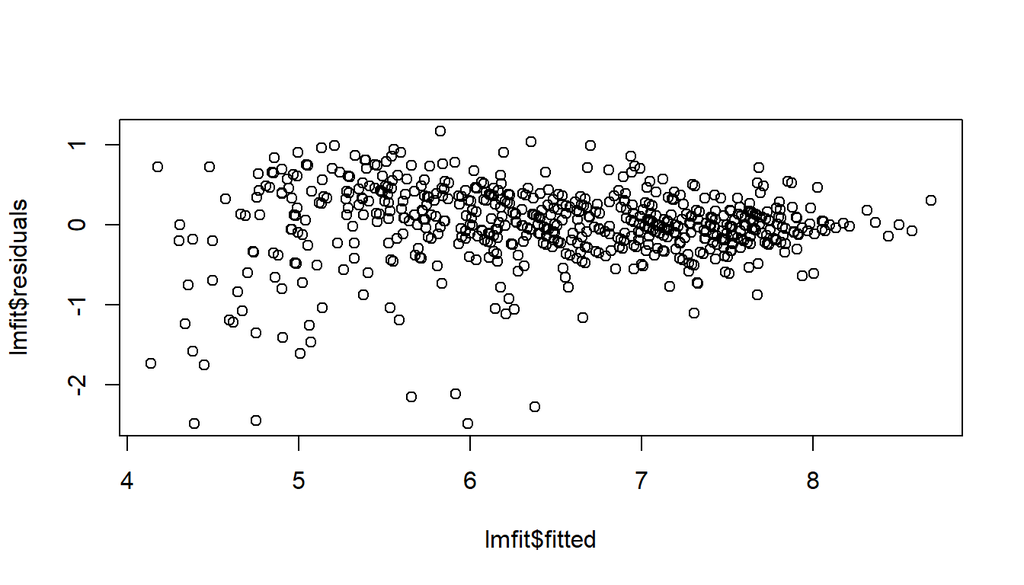

```r
# plot residuals vs fitted values
plot(lmfit$residuals ~ lmfit$fitted)
```

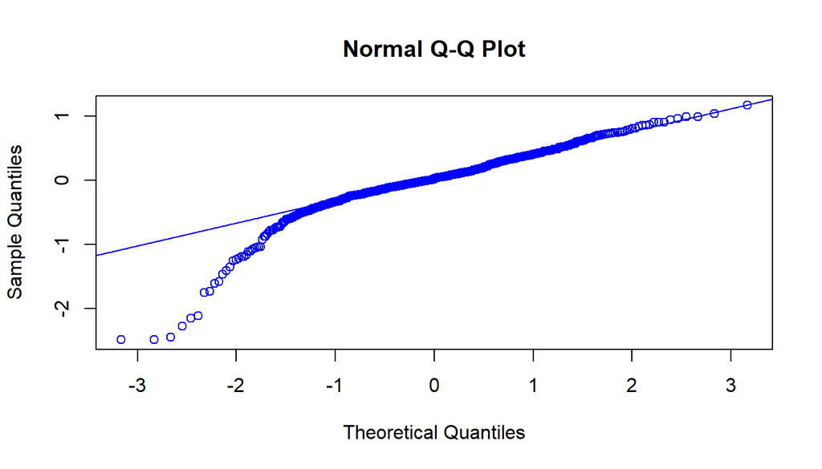

```r
# plot normal distribution, shows left skew as in the histogram. This could be explained by the high_num_votes even for low imdb_ratings

qqnorm(lmfit$residuals,col='blue')
qqline(lmfit$residuals,col='blue')
```

## Part 5: Prediction

I have picked 2 movies from the omitted rows 645-651 to test the prediction as mentioned earlier.

- The Tarzan, with critics score of 88, imdb_num_votes at 134,270 and audience score at 74
- The “Dance of the Dead”, with critics score of 87, imdb_num_votes at 10,087 and audience score at 52

The predict model is run with these 2 movie data

```r
testmovie <- data.frame(title =c("Tarzan","Dance of the Dead"), critics_score = c(88,87),imdb_num_votes=c(134270,10087),audience_score=c(74,52))
predict(lmfit, testmovie,interval='prediction',level=0.95)
```

```
##        fit      lwr      upr
## 1 7.301441 6.357324 8.245558
## 2 6.446060 5.499915 7.392204
```

The model predicts at a 95% confidence:

- Tarzan will have an imdb_rating of in the interval (6.35,8.24); (actual is 7.2)
- The Dance of the Dead to have imdb_rating in the interval (5.49,7.39); (actual is 5.9)

## Part 6: Conclusion

I set out to determine any linear relationship between imdb_score and other variables. The relationship was narrowed down to:

- imdb_rating ~ imdb_num_votes + critics_score + audience_score

- The sample data on certain variables like imdb_num_votes is skewed and does appear to normal, but given the sample size > 30, have included it in the model.
- The model was tested with 2 movies having large variation in the explanatory variables(compared to the mean) with satisfactory results

I think there would be room for improvement using a classification model to predict variables such as top200_box or nomination.